# 多元统计分析--理论与代码总结

> 这部分打算好好写一写,算作是这门课的一个总结,之后把"导论"看完,总结完方法也写到这里. 介绍每种方法的原理之后附上测试代码,对于重合的部分,尽量选择一个精简的案例.

## 1.统计准备

### 1.1 描述性统计

> 这里主要是查看数据的分布情况,主要的方法有:summary, pastecs和psych包中describe的方法;以及sapply,lapply等方法;聚集函数aggregate...  
> 上面提到的这些方法在"*3.数据管理.RMD*"和"*常用函数.Rmd*"中都有提到,这里聚焦的是统计方法,就不展开.

```r
summary(mtcars)
```

```
      mpg             cyl             disp             hp
 Min.   :10.40   Min.   :4.000   Min.   : 71.1   Min.   : 52.0
 1st Qu.:15.43   1st Qu.:4.000   1st Qu.:120.8   1st Qu.: 96.5
 Median :19.20   Median :6.000   Median :196.3   Median :123.0
 Mean   :20.09   Mean   :6.188   Mean   :230.7   Mean   :146.7
 3rd Qu.:22.80   3rd Qu.:8.000   3rd Qu.:326.0   3rd Qu.:180.0
 Max.   :33.90   Max.   :8.000   Max.   :472.0   Max.   :335.0
      drat             wt             qsec             vs
 Min.   :2.760   Min.   :1.513   Min.   :14.50   Min.   :0.0000
 1st Qu.:3.080   1st Qu.:2.581   1st Qu.:16.89   1st Qu.:0.0000
 Median :3.695   Median :3.325   Median :17.71   Median :0.0000
 Mean   :3.597   Mean   :3.217   Mean   :17.85   Mean   :0.4375
 3rd Qu.:3.920   3rd Qu.:3.610   3rd Qu.:18.90   3rd Qu.:1.0000
 Max.   :4.930   Max.   :5.424   Max.   :22.90   Max.   :1.0000
       am              gear            carb
 Min.   :0.0000   Min.   :3.000   Min.   :1.000
 1st Qu.:0.0000   1st Qu.:3.000   1st Qu.:2.000
 Median :0.0000   Median :4.000   Median :2.000
 Mean   :0.4062   Mean   :3.688   Mean   :2.812
 3rd Qu.:1.0000   3rd Qu.:4.000   3rd Qu.:4.000
 Max.   :1.0000   Max.   :5.000   Max.   :8.000
```

### 1.2 频数表与列联表

> 列联表的生成这里只提供简单两种方法,如果想要更多了解可以查看"R实战"电子书编码P161之后的内容

```r
library(grid)
library(vcd)
# 生成列联表
table <- table(Arthritis$Treatment, Arthritis$Improved)
table
table(Arthritis$Treatment, Arthritis$Improved == "None")
# 添加边际和
addmargins(table, c(1, 2))
# 将列联表转换为百分比的形式
prop.table(table) * 100
```

```
          None Some Marked
  Placebo   29    7      7
  Treated   13    7     21
```

```
          FALSE TRUE
  Placebo    14   29
  Treated    28   13
```

A table: 3 × 4 of type dbl

|  | None | Some | Marked | Sum |
| --- | --- | --- | --- | --- |
| Placebo | 29 | 7 | 7 | 43 |
| Treated | 13 | 7 | 21 | 41 |
| Sum | 42 | 14 | 28 | 84 |

```
               None      Some    Marked
  Placebo 34.523810  8.333333  8.333333
  Treated 15.476190  8.333333 25.000000
```

```r
# library(qmodels)
# CrossTable(Arthritis$Treatment, Arthritis$Improved)
```

## 2.相关

### 2.1 相关系数

**解释:**  
相关性系数与显著性检验相比,相关计算的是两者之间时候存在相关性,而这种相关性不能证明存在因果关系,也不能证明没有因果关系,需要进一步验证,而相关存在可以指明哪些变量间是可能存在关系的.我们最终想要的是因果关系而不是相关.  
**R实现:**  
R可以计算多种相关系数，包括Pearson相关系数、Spearman相关系数、Kendall相关系数、偏相关系数、多分格（polychoric）相关系数和多系列（polyserial）相关系数。  
**代码解释:**

```
{r}
cor(x, use=, method=)
```

use: 指定缺失值处理方法.可选的方式为all.obs(假遇到缺失数据时将报错); everything(遇到缺失数据时,相关系数的计算结果将被设为missing); complete.obs(行删除)以及pairwise.complete.obs(成对删除,pairwise deletion)  
method: 指定相关系数的类型.可选类型为pearson、spearman或kendall

```r
states <- state.x77[,1:6]
cor(states)
```

A matrix: 6 × 6 of type dbl

|  | Population | Income | Illiteracy | Life Exp | Murder | HS Grad |
| --- | --- | --- | --- | --- | --- | --- |
| Population | 1.00000000 | 0.2082276 | 0.1076224 | -0.06805195 | 0.3436428 | -0.09848975 |
| Income | 0.20822756 | 1.0000000 | -0.4370752 | 0.34025534 | -0.2300776 | 0.61993232 |
| Illiteracy | 0.10762237 | -0.4370752 | 1.0000000 | -0.58847793 | 0.7029752 | -0.65718861 |
| Life Exp | -0.06805195 | 0.3402553 | -0.5884779 | 1.00000000 | -0.7808458 | 0.58221620 |
| Murder | 0.34364275 | -0.2300776 | 0.7029752 | -0.78084575 | 1.0000000 | -0.48797102 |
| HS Grad | -0.09848975 | 0.6199323 | -0.6571886 | 0.58221620 | -0.4879710 | 1.00000000 |

### 2.2 协方差

**公式:** $cov(x, y) = \frac{1}{N}\sum_{i=1}^n(x_i - E(x))(y_i - E(y))$  
**代码解释:**

```
{r}
# 参数同cor
cov(x, use=, method=)
```

更多内容见"*R实战*"电子编码P170

```r
cov(states)
```

A matrix: 6 × 6 of type dbl

|  | Population | Income | Illiteracy | Life Exp | Murder | HS Grad |
| --- | --- | --- | --- | --- | --- | --- |
| Population | 19931683.7588 | 571229.7796 | 292.8679592 | -407.8424612 | 5663.523714 | -3551.509551 |
| Income | 571229.7796 | 377573.3061 | -163.7020408 | 280.6631837 | -521.894286 | 3076.768980 |
| Illiteracy | 292.8680 | -163.7020 | 0.3715306 | -0.4815122 | 1.581776 | -3.235469 |
| Life Exp | -407.8425 | 280.6632 | -0.4815122 | 1.8020204 | -3.869480 | 6.312685 |
| Murder | 5663.5237 | -521.8943 | 1.5817755 | -3.8694804 | 13.627465 | -14.549616 |
| HS Grad | -3551.5096 | 3076.7690 | -3.2354694 | 6.3126849 | -14.549616 | 65.237894 |

### 2.3 相关检验

**解释:**
即相关性的显著性检验,这里使用了符合t分布的统计量γ计算显著性.
$$ t(n-2) = \frac{γ_{xy}\sqrt{n-2}}{\sqrt{1-γ_{xy}^2}}, \quad γ(X,Y) = \frac{\sum_{i=1}^n (x_i-\bar x)(y_i-\bar y)}{\sqrt{\sum_{i=1}^n (x_i-\bar x)^2 \sum_{i=1}^n (y_i-\bar y)^2}} $$
**代码解释:**

```
{r}
cor.test(x1, x2)
```

```r
cor.test(states[,3], states[,5])
# 即有相当小的概率有0.7左右的相关性
```

```
	Pearson's product-moment correlation

data:  states[, 3] and states[, 5]
t = 6.8479, df = 48, p-value = 1.258e-08
alternative hypothesis: true correlation is not equal to 0
95 percent confidence interval:
 0.5279280 0.8207295
sample estimates:
      cor
0.7029752
```

## 3.显著性检验

### 3.1 卡方检验

**原理:**
卡方检验用于检测两个或多个定类变量之间是否存在差异,如果卡方统计量出现的概率过小我们就认为两者存在差异.
卡方统计量的定义如下:
$$X^2 = \sum\frac{(A-T)^2}{T} \quad (n = (row-1) \times (col-1), \quad T_{ij} = \frac{row\_sum_i \times col\_sum_j}{all\_sum}), \quad X^2 = \sum_{i=1}^n(\frac{X_i - μ}{σ})^2$$

其中A与T产生于下面的列联表:

|  | y1 | y2 | sum |
| --- | --- | --- | --- |
| **x1** | **A11, *T11*** | **A12, *T12*** | **R1** |
| **x2** | **A21, *T21*** | **A22, *T22*** | **R2** |
| **sum** | **C1** | **C2** | **S** |

**函数解释:**

```
{r}
chisq.test(x, y=NULL, correct=TRUE, p=rep(1/length(x),length(x)),
    rescale.p=FALSE, simulate.p.value=FALSE, B = 2000)
```

x为向量或矩阵. 若x是一维的且y不给出(y=NULL), 则chisq.test()函数用于拟和优度检验, 这时是检验总体概率是否与给定的p相同, p缺省表示进行等可能性检验; x与y同时给出时则进行列联表检验.

```
{r}
fisher.test(x, y=NULL, workspace=200000, hybrid=FALSE,
    control=list(), or=1, alternative="two.sided", conf.int=TRUE,
    conf.level=0.95, simulate.p.value=FALSE, B=2000)
```

fisher检验用于20%以上的格子的期望频数小于5的情况,修正由于某些位置观测过小的问题.  
参数workspace的值为整数, 指定工作空间的数量; 参数hybrid的值为逻辑型, 指定是否计算精确的概率, 这两个参数只在维数高于2x2的列联表中使用; 参数or指定假设的概率比率, 只在2x2列联表中使用.

```r
v <- c(35,16,15,17,17,19,11,16,30,24)
chisq.test(v)
```

```
	Chi-squared test for given probabilities

data:  v
X-squared = 24.9, df = 9, p-value = 0.003084
```

```r
compare <- matrix(c(60,32,3,11), nr = 2, dimnames = list(c("cancer", "normal"), c("smoke", "Not smoke")))
chisq.test(compare, correct=TRUE)
```

```
	Pearson's Chi-squared test with Yates' continuity correction

data:  compare
X-squared = 7.9327, df = 1, p-value = 0.004855
```

```r
compare <- matrix(c(60,32,3,11), nr = 2, dimnames = list(c("cancer", "normal"), c("smoke", "Not smoke")))
fisher.test(compare, alternative = "greater")
```

```
	Fisher's Exact Test for Count Data

data:  compare
p-value = 0.002467
alternative hypothesis: true odds ratio is greater than 1
95 percent confidence interval:
 1.950434      Inf
sample estimates:
odds ratio
   6.74691
```

### 3.2 t检验

```
{r}
t.test(x, y = NULL, alternative = c("two.sided", "less", "greater"),
    mu = 0, paired = FALSE, var.equal = FALSE, conf.level = 0.95, ...)
```

对于单类别的t检验,需要传递均值mu;两个总体则需要x与y.  
这里还包括置信区间,单边或双边检验,是否使用汇总的反差等等参数.

```r
salt <- c(490 , 506, 508, 502, 498, 511, 510, 515 , 512)
t.test(salt, mu=500)
```

```
	One Sample t-test

data:  salt
t = 2.1979, df = 8, p-value = 0.05919
alternative hypothesis: true mean is not equal to 500
95 percent confidence interval:
 499.7158 511.8398
sample estimates:
mean of x
 505.7778
```

```r
x <- c(20.5, 19.8, 19.7, 20.4, 20.1, 20.0, 19.0, 19.9)
y <- c(20.7, 19.8, 19.5, 20.8, 20.4, 19.6, 20.2)
t.test(x, y, var.equal=TRUE)
```

```
	Two Sample t-test

data:  x and y
t = -0.85485, df = 13, p-value = 0.4081
alternative hypothesis: true difference in means is not equal to 0
95 percent confidence interval:
 -0.7684249  0.3327106
sample estimates:
mean of x mean of y
 19.92500  20.14286
```

#### 3.2.1 F检验

**原理:**
F检验又叫方差齐性检验。在两样本t检验中要用到F检验。主要通过比较两组数据的方差，以确定他们的精密度是否有显著性差异。至于两组数据之间是否存在系统误差，则在进行F检验并确定它们的精密度没有显著性差异之后，再进行t检验。
公式为:$$F_{(n-1, m-1)} = \frac{\sum_{i=1}^n(x_i-\bar x)^2/(n-1)}{\sum_{j=1}^m(x_j-\bar x)^2/(m-1)}$$
计算方差是否在接受范围内,即是否方差齐次.

#### 3.2.2 Z检验与t检验

Z检验同样是进行均值比较，相比于t检验，Z检验适用于方差已知、样本量>30的情况。  
其构成的时Z统计量：$Z = \frac{X-μ}{σ}$

```
{r}
z.test(x, y = NULL, alternative = "two.sided", mu = 0, sigma.x = NULL, sigma.y = NULL, conf.level = 0.95)
```

### 3.3 方差分析

> 方差检验的针对的情况与t检验相似,检验的是不同水平下的观测对于某一变量的差异度如何,但是相比之下方差分析针对整体是否存在差异,如果确定某个水平还需要进行进一步的多重t检验或是使用同时置信区间法(Tukey法).

进行方差分析需要满足以下假设:

- 可加性:即我们对于两个变量关系的预测
- 独立正态性:即$ε_{ij}$独立同分布
- 方差齐性:比较时应该保持方差大小相同,因为我们比较均值如果不同部分离散程度较大则不一定有意义  
  方差齐次常用的检验方法为Bartlett检验和Levene检验

方差分析一般有三种情况:单因素方差分析、双因素方差分析、协方差分析.

**单因素方差分析:**  
对于n个水平的一组数据:

| 水平 | 数据 |
| --- | --- |
| level1 | x11, x12, ..., x1m |
| leveli | xi1, xi2, ..., xim |
| leveln | xn1, xn2, ..., xnm |

对于定量变量和定性变量的关系有如下的预测:$X_{ij} = μ+α_i+ε_{ij}$(μ为总平均,α为不同水平下的特征值)  
检验时作出如下假设假设:$H_0:α_1=...=α_n, \quad H_1:α_i$不全相等

其中我们想要比较的是每个不同水平均值之间的差异,所以我们有两部分方差:组间方差与组内方差,注意这里我们想要的是均值差异,但计算使用的是方差.
$$ SST = SSE + SSA, \quad SSA = \sum_{i=1}^n(\bar X_i-\bar X)^2, \quad SSE = \sum_{j=1}^m(X_{ij}-\bar X_i)^2, \quad \bar X_i = \frac{1}{m}\sum_{j=1}^mX_{ij}, \quad \bar X = \frac{1}{n}\sum_{i=1}^n\bar X_i $$

**双因素方差分析：**  
相比于单因素方差分析，需要考虑因素间的交互作用。  
双因素情况下可以通过用函数interaction.plot()作出交互效应图, 以考查因素之间交互作用是否存在。  
**协方差分析：**  
相当于在验证因子变量对预测变量的影响的同时还存在另一个数值变量也对预测变量有影响，这个时候需要先进行一次回归得到消除另一个数值变量影响后的数据进行方差分析。

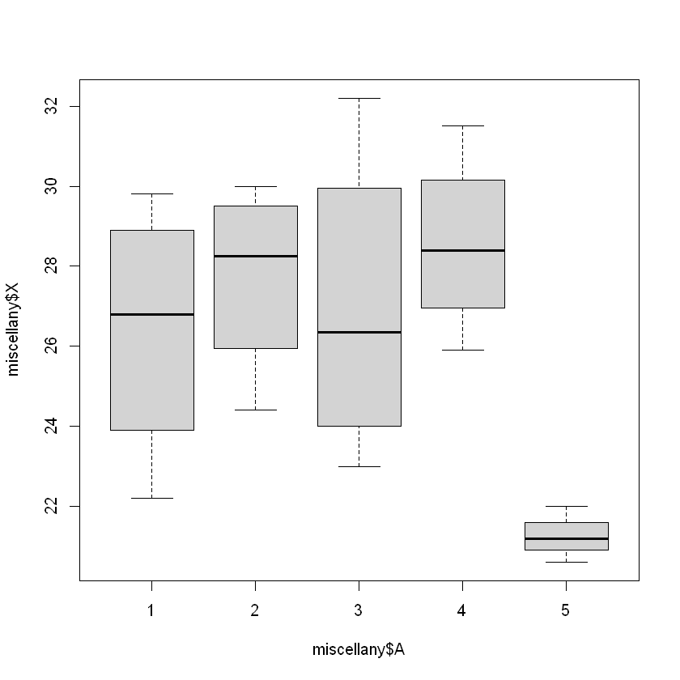

```r
# 构建数据框，生成因子变量
X <- c(25.6, 22.2, 28.0, 29.8, 24.4, 30.0, 29.0, 27.5, 25.0, 27.7, 23.0, 32.2, 28.8, 28.0, 31.5, 25.9, 20.6, 21.2, 22.0, 21.2)
A <- factor(rep(1:5, each=4))
miscellany <- data.frame(X, A)
plot(miscellany$X~miscellany$A)
```

```r
# 进行方差分析
aov.mis <- aov(X~A, data=miscellany)
summary(aov.mis)
```

```
            Df Sum Sq Mean Sq F value Pr(>F)
A            4  132.0   32.99   4.306 0.0162 *
Residuals   15  114.9    7.66
---
Signif. codes:  0 '***' 0.001 '**' 0.01 '*' 0.05 '.' 0.1 ' ' 1
```

A data.frame: 6 × 2

|  | trt <fct> | response <dbl> |
| --- | --- | --- |
| 1 | 1time | 3.861 |
| 2 | 1time | 10.387 |
| 3 | 1time | 5.906 |
| 4 | 1time | 3.061 |
| 5 | 1time | 7.720 |
| 6 | 1time | 2.714 |

```
trt
 1time 2times 4times  drugD  drugE
    10     10     10     10     10
```

A data.frame: 5 × 2

| Group.1 <fct> | x <dbl> |
| --- | --- |
| 1time | 5.782 |
| 2times | 9.225 |
| 4times | 12.375 |
| drugD | 15.361 |
| drugE | 20.948 |

A data.frame: 5 × 2

| Group.1 <fct> | x <dbl> |
| --- | --- |
| 1time | 2.878 |
| 2times | 3.483 |
| 4times | 2.923 |
| drugD | 3.455 |
| drugE | 3.345 |

```
            Df Sum Sq Mean Sq F value  Pr(>F)
trt          4   1351     338    32.4 9.8e-13 ***
Residuals   45    469      10
---
Signif. codes:  0 '***' 0.001 '**' 0.01 '*' 0.05 '.' 0.1 ' ' 1
```

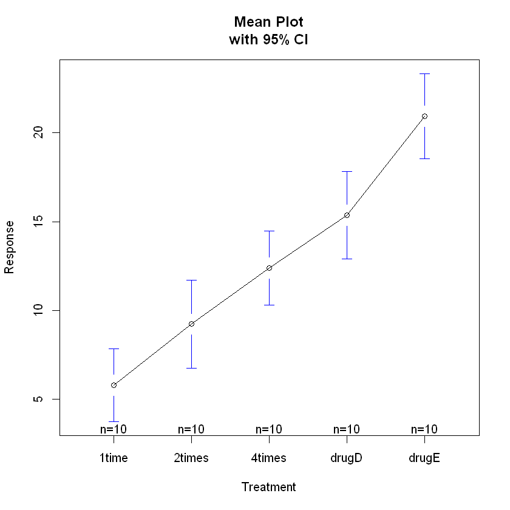

```r
# 案例
library(multcomp)
attach(cholesterol)

# 探索数据框情况
head(cholesterol)
table(trt)

# 查看数据分布
aggregate(response, by=list(trt), FUN=mean)
aggregate(response, by=list(trt), FUN=sd)

# 进行方差分析
fit <- aov(response ~ trt)
summary(fit)

# 绘制图片展示结果
library(gplots)
plotmeans(response~trt, xlab="Treatment", ylab="Response",
          main="Mean Plot\nwith 95% CI")
detach(cholesterol)
```

```r
rats<-data.frame( Time=c(0.31, 0.45, 0.46, 0.43, 0.82, 1.10, 0.88, 0.72, 0.43, 0.45, 0.63, 0.76, 0.45, 0.71, 0.66, 0.62, 0.38, 0.29, 0.40, 0.23, 0.92, 0.61, 0.49, 1.24, 0.44, 0.35, 0.31, 0.40, 0.56, 1.02, 0.71, 0.38, 0.22, 0.21, 0.18, 0.23, 0.30, 0.37, 0.38, 0.29, 0.23, 0.25, 0.24, 0.22, 0.30, 0.36, 0.31, 0.33),
                  Toxicant=gl(3, 16, 48, labels = c("I", "II", "III")), Cure=gl(4, 4, 48, labels = c("A", "B", "C", "D"))
)
rats.aov<-aov(Time~Toxicant*Cure, data=rats)
summary(rats.aov)
```

```
              Df Sum Sq Mean Sq F value   Pr(>F)
Toxicant       2 1.0356  0.5178  23.225 3.33e-07 ***
Cure           3 0.9146  0.3049  13.674 4.13e-06 ***
Toxicant:Cure  6 0.2478  0.0413   1.853    0.116
Residuals     36 0.8026  0.0223
---
Signif. codes:  0 '***' 0.001 '**' 0.01 '*' 0.05 '.' 0.1 ' ' 1
```